# **Problem Statement**

## Training Performance

The post-training evaluation produced:

| Metric | Training Result |
| --- | --- |
| Accuracy | 0.9745 |
| Macro recall | 0.9586 |
| Macro precision | 0.9698 |
| Macro F1-score | 0.9640 |

The model correctly classified approximately **97.5%** of the training images.

The macro F1-score of approximately **96.4%** indicates strong performance across both classes on the training dataset.

### Training Confusion Matrix

| Actual class | Predicted Without Helmet | Predicted With Helmet |
| --- | --- | --- |
| Without Helmet | 716 | 55 |
| With Helmet | 29 | 2,500 |

This means:

- **716** no-helmet images were correctly classified.
- **55** no-helmet images were incorrectly classified as helmeted.
- **29** helmet images were incorrectly classified as no-helmet.
- **2,500** helmet images were correctly classified.
- The model made **84 training errors**.
- The model made **3,216 correct training predictions**.

### Training Class-Specific Recall

Recall for the Without Helmet class was:

```
716 ÷ 771 = 92.9%
```

Recall for the With Helmet class was:

```
2,500 ÷ 2,529 = 98.9%
```

The model performed extremely well on both classes in the training dataset, although helmet recall remained higher than no-helmet recall.

## Validation Performance

The validation evaluation produced:

| Metric | Validation Result |
| --- | --- |
| Accuracy | 0.9199 |
| Macro recall | 0.8716 |
| Macro precision | 0.8987 |
| Macro F1-score | 0.8841 |

The model correctly classified approximately **92.0%** of the validation images.

The validation macro F1-score was approximately **88.4%**, which was notably lower than the training macro F1-score of 96.4%.

### Validation Confusion Matrix

| Actual class | Predicted Without Helmet | Predicted With Helmet |
| --- | --- | --- |
| Without Helmet | 75 | 21 |
| With Helmet | 12 | 304 |

This means:

- **75** no-helmet images were correctly classified.
- **21** no-helmet images were incorrectly classified as helmeted.
- **12** helmet images were incorrectly classified as no-helmet.
- **304** helmet images were correctly classified.
- The model made **33 validation errors**.
- The model made **379 correct validation predictions**.

The validation accuracy can be verified as:

```
(75 + 304) ÷ 412 = 91.99%
```

### Validation Class-Specific Recall

Recall for the Without Helmet class was:

```
75 ÷ 96 = 78.1%
```

Recall for the With Helmet class was:

```
304 ÷ 316 = 96.2%
```

The model was therefore substantially better at detecting helmet images than no-helmet images.

## Safety Interpretation

The most consequential validation error was the group of **21 workers without helmets who were incorrectly classified as wearing helmets**.

These errors represented:

$$ \frac{21}{96}\times100 \approx 21.9\% $$

of the actual no-helmet validation images.

In an operational safety-monitoring system, these errors could allow unsafe workers to pass through the system without being flagged.

The 12 helmet images incorrectly classified as no-helmet would generate false alarms. Although these cases could require unnecessary human review, they are generally less safety-critical than failing to flag an unprotected worker.

The overall validation accuracy of approximately 92% partially hides this weakness because the dataset contains considerably more helmet images than no-helmet images.

## Evidence of Overfitting

The differences between training and validation performance were:

| Metric | Training | Validation | Difference |
| --- | --- | --- | --- |
| Accuracy | 0.9745 | 0.9199 | 0.0546 |
| Macro recall | 0.9586 | 0.8716 | 0.0870 |
| Macro precision | 0.9698 | 0.8987 | 0.0711 |
| Macro F1-score | 0.9640 | 0.8841 | 0.0799 |

The training macro F1-score was approximately eight percentage points higher than the validation macro F1-score.

The largest decline was in macro recall, which decreased by approximately 8.7 percentage points.

These gaps indicate that Model 2 learned the training data substantially better than it generalized to unseen validation images. The results therefore provide evidence of overfitting.

Although the frozen VGG16 features are powerful, the trained classification layer appears to fit the training data more effectively than the validation data.

## Keras Recall Compared with Macro Recall

The final Keras validation recall was:

```
0.9620
```

The validation performance table reported macro recall of:

```
0.8716
```

These values measure different concepts.

Keras recall treats label `1`, **With Helmet**, as the positive class:

```
Helmet recall = 304 ÷ 316 = 96.2%
```

Recall for the no-helmet class was:

```
No-helmet recall = 75 ÷ 96 = 78.1%
```

Macro recall averages the recall values for both classes:

$$ \text{Macro Recall} = \frac{96.2\%+78.1\%}{2} \approx87.2\% $$

This explains why macro recall is substantially lower than the Keras recall.

Macro recall is more informative for this imbalanced dataset because it gives equal importance to the helmet and no-helmet classes.

## Interpretation of the Example Images

Validation images `12` and `33` are blurred and contain limited visual detail. Image `33` appears to contain a yellow safety helmet, while image `12` is substantially more ambiguous.

These examples demonstrate the difficulty of classifying low-resolution images.

The displayed image, normalized input, and true label must use the same index. The correctness of each prediction should be determined by comparing its printed predicted label with its printed true label.

The images alone do not provide enough information to establish whether both model predictions were correct.

## Model 2 Conclusion

Model 2 achieved:

- **97.5% training accuracy**
- **96.4% training macro F1-score**
- **92.0% validation accuracy**
- **88.4% validation macro F1-score**

The sizable training-validation gaps indicate overfitting.

The model correctly detected approximately:

- **96.2% of helmet validation images**
- **78.1% of no-helmet validation images**

It incorrectly classified **21 of the 96 unsafe no-helmet validation cases as helmet-compliant**.

Therefore, Model 2 should not be selected based only on its overall accuracy or label-1 recall. It should be compared with the remaining models using:

- Validation macro F1-score
- Macro recall
- No-helmet recall
- Confusion matrices
- Training-validation performance gaps
- Number of unsafe false-compliance errors

### Concise Observation for the Presentation

The frozen VGG16 base achieved 97.5% training accuracy but only 92.0% validation accuracy, indicating overfitting. Validation macro F1-score was 88.4%. The model identified 96.2% of helmet images but only 78.1% of no-helmet images, incorrectly classifying 21 of 96 unsafe cases as helmet-compliant. These results demonstrate why overall accuracy and standard label-1 recall overstate the model's effectiveness for safety monitoring.

## Model 3: Transfer Learning with VGG-16 (Base + FFNN)

- We will directly use the convolutional and pooling layers and freeze their weights i.e. no training will be done on them. For classification, we will add a Flatten layer and a Feed Forward Neural Network.

```python
model_3 = Sequential()

# Adding the convolutional part of the VGG16 model from above
model_3.add(vgg_model)

# Flattening the output of the VGG16 model because it is from a convolutional layer
model_3.add(Flatten())

#Adding the Feed Forward neural network
model_3.add(Dense(64,activation='relu')) #Complete the code to define the number of neurons and the activation function
model_3.add(Dropout(rate=0.30)) #Complete the code to define the dropout rate
model_3.add(Dense(32,activation='relu')) #Complete the code to define the number of neurons and the activation function

# Adding a dense output layer
model_3.add(Dense(1, activation='sigmoid')) #Complete the code to define the number of neurons in the output layer and the activation function
```

```python
opt = Adam(learning_rate=0.0001) #Complete the code to define the learning rate
```

```python
# Compile model
model_3.compile(optimizer=opt,loss=keras.losses.BinaryCrossentropy(), metrics=["recall"]) #Complete the code to define the metrics
```

```python
# Generating the summary of the model
model_3.summary()
```

```
Model: "sequential_2"
```

```
┏━━━━━━━━━━━━━━━━━━━━━━━━━━━━━━━━━┳━━━━━━━━━━━━━━━━━━━━━━━━┳━━━━━━━━━━━━━━━┓
┃ Layer (type)                    ┃ Output Shape           ┃       Param # ┃
┡━━━━━━━━━━━━━━━━━━━━━━━━━━━━━━━━━╇━━━━━━━━━━━━━━━━━━━━━━━━╇━━━━━━━━━━━━━━━┩
│ vgg16 (Functional)              │ (None, 6, 6, 512)      │    14,714,688 │
├─────────────────────────────────┼────────────────────────┼───────────────┤
│ flatten_2 (Flatten)             │ (None, 18432)          │             0 │
├─────────────────────────────────┼────────────────────────┼───────────────┤
│ dense_3 (Dense)                 │ (None, 64)             │     1,179,712 │
├─────────────────────────────────┼────────────────────────┼───────────────┤
│ dropout (Dropout)               │ (None, 64)             │             0 │
├─────────────────────────────────┼────────────────────────┼───────────────┤
│ dense_4 (Dense)                 │ (None, 32)             │         2,080 │
├─────────────────────────────────┼────────────────────────┼───────────────┤
│ dense_5 (Dense)                 │ (None, 1)              │            33 │
└─────────────────────────────────┴────────────────────────┴───────────────┘
```

```
 Total params: 18,260,165 (69.66 MB)
```

```
 Trainable params: 1,181,825 (4.51 MB)
```

```
 Non-trainable params: 14,714,688 (56.13 MB)
```

```
 Optimizer params: 2,363,652 (9.02 MB)
```

```python
history_3 = model_3.fit(train_datagen.flow(X_train_normalized,y_train,
                                       batch_size=16, #Complete the code to define the batch size
                                       seed=42,
                                       shuffle=False),
                    epochs=10, #Complete the code to define the number of epochs
                    steps_per_epoch=X_train_normalized.shape[0] // batch_size,
                    validation_data=(X_val_normalized,y_val),
                    verbose=1)
```

```
206/206 ━━━━━━━━━━━━━━━━━━━━ 22s 94ms/step - loss: 0.4477 - recall: 0.9531 - val_loss: 0.3202 - val_recall: 0.9905
206/206 ━━━━━━━━━━━━━━━━━━━━ 2s 11ms/step - loss: 0.1915 - recall: 1.0000 - val_loss: 0.3172 - val_recall: 0.9873
206/206 ━━━━━━━━━━━━━━━━━━━━ 18s 87ms/step - loss: 0.3097 - recall: 0.9551 - val_loss: 0.2803 - val_recall: 0.9905
206/206 ━━━━━━━━━━━━━━━━━━━━ 2s 9ms/step - loss: 0.3213 - recall: 1.0000 - val_loss: 0.2786 - val_recall: 0.9905
206/206 ━━━━━━━━━━━━━━━━━━━━ 17s 81ms/step - loss: 0.2582 - recall: 0.9539 - val_loss: 0.2309 - val_recall: 0.9304
206/206 ━━━━━━━━━━━━━━━━━━━━ 2s 9ms/step - loss: 0.2865 - recall: 0.8462 - val_loss: 0.2305 - val_recall: 0.9304
206/206 ━━━━━━━━━━━━━━━━━━━━ 16s 80ms/step - loss: 0.2234 - recall: 0.9535 - val_loss: 0.2134 - val_recall: 0.9747
206/206 ━━━━━━━━━━━━━━━━━━━━ 2s 9ms/step - loss: 0.1776 - recall: 1.0000 - val_loss: 0.2074 - val_recall: 0.9525
206/206 ━━━━━━━━━━━━━━━━━━━━ 19s 82ms/step - loss: 0.2058 - recall: 0.9575 - val_loss: 0.2116 - val_recall: 0.9778
206/206 ━━━━━━━━━━━━━━━━━━━━ 2s 10ms/step - loss: 0.2265 - recall: 1.0000 - val_loss: 0.2128 - val_recall: 0.9810
```

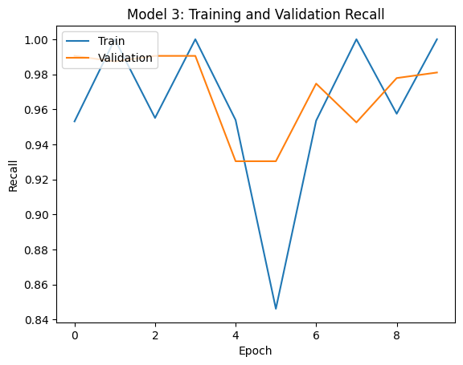

```python
plt.plot(history_3.history['recall']) #Complete the code to plot the train metrics
plt.plot(history_3.history['val_recall']) #Complete the code to plot the validation data metrics
plt.title("Model 3: Training and Validation Recall") #Complete the code to define the title for the plot
plt.ylabel('Recall') #Complete the code to define the label for the y-axis
plt.xlabel('Epoch') #Complete the code to define the label for the x-axis
plt.legend(['Train', 'Validation'], loc='upper left')
plt.show()
```

```python
model_3_train_perf = model_performance_classification(model_3, X_train_normalized,y_train)

print("Train performance metrics")
print(model_3_train_perf)
```

```
104/104 ━━━━━━━━━━━━━━━━━━━━ 16s 147ms/step
Train performance metrics
   Accuracy    Recall  Precision  F1 Score
0   0.94697  0.905445   0.943736  0.922703
```

```
104/104 ━━━━━━━━━━━━━━━━━━━━ 16s 145ms/step
```

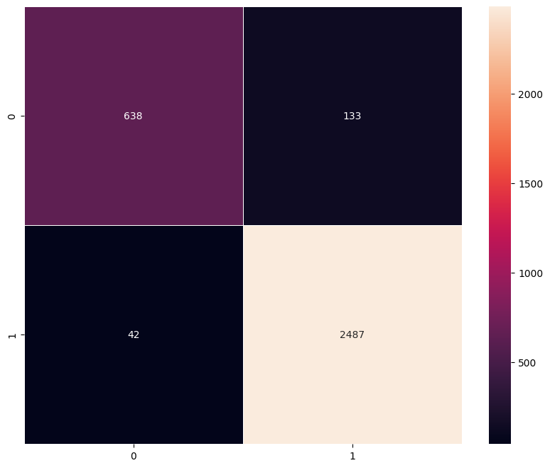

```python
plot_confusion_matrix(model_3,X_train_normalized,y_train)
```

```python
model_3_valid_perf = model_performance_classification(model_3, X_val_normalized,y_val)

print("Validation performance metrics")
print(model_3_valid_perf)
```

```
13/13 ━━━━━━━━━━━━━━━━━━━━ 2s 149ms/step
Validation performance metrics
   Accuracy    Recall  Precision  F1 Score
0  0.919903  0.849881   0.919941  0.878241
```

```
13/13 ━━━━━━━━━━━━━━━━━━━━ 2s 146ms/step
```

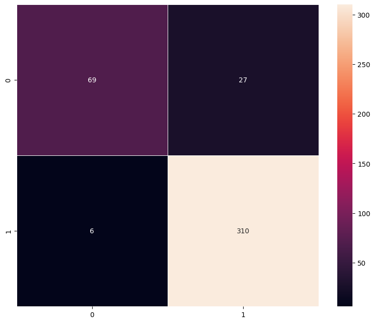

```python
plot_confusion_matrix(model_3,X_val_normalized,y_val)
```

#### Visualizing the predictions

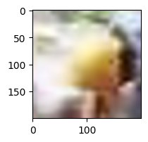

```
1/1 ━━━━━━━━━━━━━━━━━━━━ 0s 87ms/step
Predicted Label: 1
True Label: 1
```

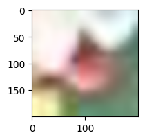

```
1/1 ━━━━━━━━━━━━━━━━━━━━ 0s 55ms/step
Predicted Label: 1
True Label: 1
```

```python
plt.figure(figsize=(2,2))
plt.imshow(X_val[33]) #Complete the code to define the index
plt.show()
prediction = model_3.predict(X_val_normalized[33].reshape(1,200,200,3)) #Complete the code to define the index
predicted_label = prediction[0][0]>0.5  # Extract the predicted class label
print('Predicted Label:', 1 if predicted_label else 0)
# Fix indexing issue in y_val
true_label = y_val.iloc[33,0] #Complete the code to define the index
print('True Label:', true_label)

plt.figure(figsize=(2,2))
plt.imshow(X_val[12]) #Complete the code to define the index
plt.show()
prediction = model_3.predict(X_val_normalized[12].reshape(1,200,200,3)) #Complete the code to define the index
predicted_label = prediction[0][0]>0.5  # Extract the predicted class label
print('Predicted Label:', 1 if predicted_label else 0)
# Fix indexing issue in y_val
true_label = y_val.iloc[12,0] #Complete the code to define the index
print('True Label:', true_label)
```

## Model 3: VGG16 Base with a Feed-Forward Neural Network

### Model Configuration

Model 3 uses the frozen VGG16 convolutional base as a pretrained feature extractor. The original VGG16 classification layers were removed and replaced with a custom feed-forward neural network.

The classification head contained:

- A `Flatten` layer
- A dense layer with 64 neurons and ReLU activation
- A dropout layer with a rate of `0.30`
- A dense layer with 32 neurons and ReLU activation
- One sigmoid output neuron for binary classification

The VGG16 layers remained frozen, so only the custom dense classification layers were trained.

The model used:

- **Optimizer:** Adam
- **Learning rate:** `0.0001`
- **Loss:** Binary cross-entropy
- **Batch size:** `16`
- **Training epochs:** `10`
- **Tracked Keras metric:** Recall
- **Data augmentation:** None

The dropout layer randomly deactivated 30% of its inputs during training to reduce dependence on individual features and potentially limit overfitting.

> **Training note:** The generator used `shuffle=False`, meaning the images were processed in the same order during training. Shuffling would generally be preferable because it changes the batch composition across epochs.

## Training History

### Loss

Training loss began at `0.4477` in Epoch 1 and ended at `0.2265` in Epoch 10.

Validation loss decreased from `0.3202` to `0.2128`. The lowest validation loss was approximately `0.2074` in Epoch 8.

The decline in validation loss indicates that the model learned features that generalized to unseen validation images. The slight increase after Epoch 8 suggests that further training did not consistently improve validation loss.

### Recall

Training recall and validation recall remained high but fluctuated across epochs.

Training recall ranged from approximately:

```
84.6% to 100.0%
```

Validation recall ranged from approximately:

```
93.0% to 99.1%
```

The final validation recall was:

```
98.1%
```

This Keras recall measures only label `1`, **With Helmet**. It does not directly measure how effectively the model identifies workers without helmets.

The volatility in the recall curves indicates that recall alone should not be used to select the final model. Macro metrics and confusion matrices provide a more balanced assessment.

## Training Performance

The final training metrics were:

| Metric | Training Result |
| --- | --- |
| Accuracy | 0.9470 |
| Macro recall | 0.9054 |
| Macro precision | 0.9437 |
| Macro F1-score | 0.9227 |

The model correctly classified approximately **94.7%** of the 3,300 training images.

### Training Confusion Matrix

| Actual class | Predicted Without Helmet | Predicted With Helmet |
| --- | --- | --- |
| Without Helmet | 638 | 133 |
| With Helmet | 42 | 2,487 |

This means:

- **638** no-helmet images were classified correctly.
- **133** no-helmet images were incorrectly classified as helmeted.
- **42** helmet images were incorrectly classified as no-helmet.
- **2,487** helmet images were classified correctly.
- The model made **175 training errors**.
- The model made **3,125 correct training predictions**.

### Training Class-Specific Recall

Recall for the Without Helmet class was:

```
638 ÷ 771 = 82.7%
```

Recall for the With Helmet class was:

```
2,487 ÷ 2,529 = 98.3%
```

The model was considerably better at recognizing helmet images than no-helmet images, even on the training dataset.

## Validation Performance

The validation metrics were:

| Metric | Validation Result |
| --- | --- |
| Accuracy | 0.9199 |
| Macro recall | 0.8499 |
| Macro precision | 0.9199 |
| Macro F1-score | 0.8782 |

The model correctly classified approximately **92.0%** of the 412 validation images.

### Validation Confusion Matrix

| Actual class | Predicted Without Helmet | Predicted With Helmet |
| --- | --- | --- |
| Without Helmet | 69 | 27 |
| With Helmet | 6 | 310 |

This means:

- **69** no-helmet images were classified correctly.
- **27** no-helmet images were incorrectly classified as helmeted.
- **6** helmet images were incorrectly classified as no-helmet.
- **310** helmet images were classified correctly.
- The model made **33 validation errors**.
- The model made **379 correct validation predictions**.

The validation accuracy can be verified as:

```
(69 + 310) ÷ 412 = 92.0%
```

### Validation Class-Specific Recall

Recall for the Without Helmet class was:

```
69 ÷ 96 = 71.9%
```

Recall for the With Helmet class was:

```
310 ÷ 316 = 98.1%
```

The model was much more effective at identifying helmet images than no-helmet images.

## Safety Interpretation

The most consequential errors were the **27 no-helmet images incorrectly classified as helmeted**.

These errors represented:

$$ \frac{27}{96}\times100 \approx 28.1\% $$

of the actual no-helmet validation images.

In practical terms, Model 3 failed to flag more than one out of every four no-helmet images in the validation dataset.

Although Model 3 achieved approximately 92% validation accuracy and very high macro precision, those metrics conceal its weak detection of the minority no-helmet class.

The model produced only six false alarms on helmet images, but it did so by favoring the With Helmet prediction. This reduced false alarms while increasing the number of unsafe no-helmet cases incorrectly classified as compliant.

## Training-to-Validation Generalization

| Metric | Training | Validation | Difference |
| --- | --- | --- | --- |
| Accuracy | 0.9470 | 0.9199 | 0.0271 |
| Macro recall | 0.9054 | 0.8499 | 0.0556 |
| Macro precision | 0.9437 | 0.9199 | 0.0238 |
| Macro F1-score | 0.9227 | 0.8782 | 0.0445 |

Validation performance was approximately two to six percentage points lower than training performance.

The largest decline occurred in macro recall. This indicates that the model generalized less effectively across both classes, particularly for the minority no-helmet class.

The training-validation gap provides evidence of moderate overfitting, even with the 30% dropout layer.

## Keras Recall Compared with Macro Recall

The final Keras validation recall was:

```
0.9810
```

The validation performance table reported macro recall of:

```
0.8499
```

These values measure different concepts.

Keras recall treats label `1`, **With Helmet**, as the positive class:

```
Helmet recall = 310 ÷ 316 = 98.1%
```

Recall for the no-helmet class was:

```
No-helmet recall = 69 ÷ 96 = 71.9%
```

Macro recall gives both classes equal importance:

$$ \text{Macro Recall} = \frac{98.1\%+71.9\%}{2} \approx85.0\% $$

This explains why the macro recall is substantially lower than the Keras recall.

The result also demonstrates why standard Keras recall can be misleading for this project: it emphasizes the majority helmet class rather than the more safety-critical no-helmet class.

## Comparison with Model 2

Models 2 and 3 achieved the same validation accuracy:

```
91.99%
```

However, their error patterns differed:

| Metric | Model 2 | Model 3 |
| --- | --- | --- |
| Validation accuracy | 0.9199 | 0.9199 |
| Macro recall | **0.8716** | 0.8499 |
| Macro precision | 0.8987 | **0.9199** |
| Macro F1-score | **0.8841** | 0.8782 |
| No-helmet cases missed | **21** | 27 |
| Helmet false alarms | 12 | **6** |

Adding the feed-forward neural network increased macro precision and reduced false alarms on helmet images. However, it also increased the number of unsafe no-helmet cases incorrectly classified as helmeted.

Model 3 therefore traded recall for precision. That tradeoff is not desirable for this safety application because failing to identify an unprotected worker is more consequential than generating an additional review alert.

## Example Validation Images

Validation images `12` and `33` are blurred and contain limited visual detail. These images demonstrate the difficulty of classifying low-resolution and ambiguous examples.

The displayed images, normalized inputs, and true labels use consistent indices. The correctness of each prediction should be determined by comparing its printed predicted label with its printed true label.

The image alone should not be used to conclude whether the model prediction was correct, particularly for the heavily blurred example.

## Model 3 Conclusion

Model 3 achieved:

- **94.7% training accuracy**
- **92.0% validation accuracy**
- **92.0% validation macro precision**
- **87.8% validation macro F1-score**

The model demonstrated high precision and excellent helmet recall. However, its validation recall for no-helmet images was only **71.9%**.

The model incorrectly classified **27 of the 96 no-helmet validation images as helmet-compliant**, representing approximately **28.1% of the unsafe validation cases**.

The addition of the feed-forward neural network improved precision but produced a less balanced result than Model 2. Model 3 should therefore not be selected solely because it achieved the highest validation precision.

For this safety application, macro F1-score, macro recall, no-helmet recall, and the number of unsafe false-compliance errors provide stronger selection criteria.

### Concise Observation for the Presentation

Model 3 achieved 92.0% validation accuracy and the highest validation macro precision at 92.0%. However, validation macro recall declined to 85.0%, and the model correctly identified only 71.9% of no-helmet images. It incorrectly classified 27 of 96 unsafe cases as helmet-compliant. The FFNN reduced false alarms but increased missed safety violations, making Model 3 less suitable than a more balanced model.

## Model 4: Transfer Learning with VGG-16 (Base + FFNN + Data Augmentation)

- In most of the real-world case studies, it is challenging to acquire a large number of images and then train CNNs.
- To overcome this problem, one approach we might consider is **Data Augmentation**.
- CNNs have the property of **translational invariance**, which means they can recognise an object even if its appearance shifts translationally in some way. - Taking this attribute into account, we can augment the images using the techniques listed below
  - Horizontal Flip (should be set to True/False)
  - Vertical Flip (should be set to True/False)
  - Height Shift (should be between 0 and 1)
  - Width Shift (should be between 0 and 1)
  - Rotation (should be between 0 and 180)
  - Shear (should be between 0 and 1)
  - Zoom (should be between 0 and 1) etc.

Remember, **data augmentation should not be used in the validation/test data set**.

```python
model_4 = Sequential()

# Adding the convolutional part of the VGG16 model from above
model_4.add(vgg_model)

# Flattening the output of the VGG16 model because it is from a convolutional layer
model_4.add(Flatten())

#Adding the Feed Forward neural network
model_4.add(Dense(64,activation='relu')) #Complete the code to define the number of neurons and the activation function
model_4.add(Dropout(rate=0.30)) #Complete the code to define the dropout rate
model_4.add(Dense(32,activation='relu')) #Complete the code to define the number of neurons and the activation function

# Adding a dense output layer
model_4.add(Dense(1, activation='sigmoid')) #Complete the code to define the number of neurons in the output layer and the actiavtion function
```

```python
# Ensure the VGG16 base remains frozen
for layer in vgg_model.layers:
    layer.trainable = False

# Rebuild Model 4 from scratch
model_4 = Sequential()

model_4.add(vgg_model)
model_4.add(Flatten())

model_4.add(
    Dense(
        64,
        activation="relu"
    )
)

model_4.add(
    Dropout(
        rate=0.30
    )
)

model_4.add(
    Dense(
        32,
        activation="relu"
    )
)

model_4.add(
    Dense(
        1,
        activation="sigmoid"
    )
)

# Compile the newly created model
model_4.compile(
    optimizer=Adam(learning_rate=0.0001),
    loss="binary_crossentropy",
    metrics=[
        tf.keras.metrics.Recall(name="recall")
    ]
)

model_4.summary()
```

```
Model: "sequential_4"
```

```
┏━━━━━━━━━━━━━━━━━━━━━━━━━━━━━━━━━┳━━━━━━━━━━━━━━━━━━━━━━━━┳━━━━━━━━━━━━━━━┓
┃ Layer (type)                    ┃ Output Shape           ┃       Param # ┃
┡━━━━━━━━━━━━━━━━━━━━━━━━━━━━━━━━━╇━━━━━━━━━━━━━━━━━━━━━━━━╇━━━━━━━━━━━━━━━┩
│ vgg16 (Functional)              │ (None, 6, 6, 512)      │    14,714,688 │
├─────────────────────────────────┼────────────────────────┼───────────────┤
│ flatten_4 (Flatten)             │ (None, 18432)          │             0 │
├─────────────────────────────────┼────────────────────────┼───────────────┤
│ dense_9 (Dense)                 │ (None, 64)             │     1,179,712 │
├─────────────────────────────────┼────────────────────────┼───────────────┤
│ dropout_2 (Dropout)             │ (None, 64)             │             0 │
├─────────────────────────────────┼────────────────────────┼───────────────┤
│ dense_10 (Dense)                │ (None, 32)             │         2,080 │
├─────────────────────────────────┼────────────────────────┼───────────────┤
│ dense_11 (Dense)                │ (None, 1)              │            33 │
└─────────────────────────────────┴────────────────────────┴───────────────┘
```

```
 Total params: 15,896,513 (60.64 MB)
```

```
 Trainable params: 1,181,825 (4.51 MB)
```

```
 Non-trainable params: 14,714,688 (56.13 MB)
```

```python
#opt=Adam(learning_rate=0.0001)
# Compile model
#model_4.compile(optimizer=opt,   loss=keras.losses.BinaryCrossentropy(), metrics=["_____"]) #Complete the code to define the metrics
```

```python
# Generating the summary of the model
#model_4.summary()
```

```python
y_train_array = (
    y_train["label"]
    .to_numpy(dtype=np.float32)
)

y_val_array = (
    y_val["label"]
    .to_numpy(dtype=np.float32)
)

print("Training labels:", y_train_array.shape)
print("Validation labels:", y_val_array.shape)
print("Training label type:", y_train_array.dtype)
```

```
Training labels: (3300,)
Validation labels: (412,)
Training label type: float32
```

```python
augmented_train_datagen = ImageDataGenerator(
    rotation_range=15,
    fill_mode="nearest",
    width_shift_range=0.10,
    height_shift_range=0.10,
    shear_range=0.10,
    zoom_range=0.10,
    horizontal_flip=True,
    vertical_flip=False
)
```

```python
# Applying data augmentation
# Applying data augmentation
#train_datagen = ImageDataGenerator(
    #rotation_range=15,        # Complete the code to define the range for rotation
   # fill_mode='nearest',
   # width_shift_range=0.10,     # Complete the code to define the width shift range
   # height_shift_range=0.10,    # Complete the code to define the height shift range
   # shear_range=0.10,           # Complete the code to define the shear range
   # zoom_range=0.10             # Complete the code to define the zoom range
#)
```

```python
#history_4 = model_4.fit(train_datagen.flow(X_train_normalized,y_train,
                                       #batch_size=16, #Complete the code to define the batch size
                                       #seed=42,
                                       #shuffle=False),
                    #epochs=epochs,
                    #steps_per_epoch=X_train_normalized.shape[0] // batch_size,
                    #validation_data=(X_val_normalized,y_val),
                    #verbose=1)
```

```python
train_generator_4 = augmented_train_datagen.flow(
    X_train_normalized,
    y_train_array,
    batch_size=16,
    seed=42,
    shuffle=True
)
```

```python
sample_X, sample_y = next(train_generator_4)

print("Image batch shape:", sample_X.shape)
print("Label batch shape:", sample_y.shape)
print("Image data type:", sample_X.dtype)
print("Label data type:", sample_y.dtype)

train_generator_4.reset()
```

```
Image batch shape: (16, 200, 200, 3)
Label batch shape: (16,)
Image data type: float32
Label data type: float32
```

```python
print("Optimizer:", model_4.optimizer)
print("Loss:", model_4.loss)
print(
    "Number of trainable weight tensors:",
    len(model_4.trainable_weights)
)
```

```
Optimizer: <keras.src.optimizers.adam.Adam object at 0x7983b8692ea0>
Loss: binary_crossentropy
Number of trainable weight tensors: 6
```

```python
history_4 = model_4.fit(
    train_generator_4,
    epochs=10,
    validation_data=(
        X_val_normalized,
        y_val_array
    ),
    verbose=1
)
```

```
207/207 ━━━━━━━━━━━━━━━━━━━━ 52s 243ms/step - loss: 0.4341 - recall: 0.9636 - val_loss: 0.3151 - val_recall: 0.9905
207/207 ━━━━━━━━━━━━━━━━━━━━ 51s 245ms/step - loss: 0.3411 - recall: 0.9526 - val_loss: 0.2808 - val_recall: 0.9905
207/207 ━━━━━━━━━━━━━━━━━━━━ 49s 236ms/step - loss: 0.3110 - recall: 0.9427 - val_loss: 0.2385 - val_recall: 0.9494
207/207 ━━━━━━━━━━━━━━━━━━━━ 49s 236ms/step - loss: 0.2841 - recall: 0.9454 - val_loss: 0.2241 - val_recall: 0.9462
207/207 ━━━━━━━━━━━━━━━━━━━━ 51s 244ms/step - loss: 0.2725 - recall: 0.9486 - val_loss: 0.2268 - val_recall: 0.8987
207/207 ━━━━━━━━━━━━━━━━━━━━ 49s 237ms/step - loss: 0.2524 - recall: 0.9490 - val_loss: 0.2056 - val_recall: 0.9715
207/207 ━━━━━━━━━━━━━━━━━━━━ 49s 235ms/step - loss: 0.2387 - recall: 0.9490 - val_loss: 0.2072 - val_recall: 0.9747
207/207 ━━━━━━━━━━━━━━━━━━━━ 50s 241ms/step - loss: 0.2384 - recall: 0.9482 - val_loss: 0.1893 - val_recall: 0.9335
207/207 ━━━━━━━━━━━━━━━━━━━━ 53s 255ms/step - loss: 0.2384 - recall: 0.9510 - val_loss: 0.1941 - val_recall: 0.9620
207/207 ━━━━━━━━━━━━━━━━━━━━ 55s 269ms/step - loss: 0.2285 - recall: 0.9529 - val_loss: 0.1855 - val_recall: 0.9557
```

```python
# Convert labels from DataFrames to one-dimensional arrays
y_train_array = (
    y_train["label"]
    .to_numpy(dtype=np.float32)
)

y_val_array = (
    y_val["label"]
    .to_numpy(dtype=np.float32)
)

# Configure augmentation for training images only
augmented_train_datagen = ImageDataGenerator(
    rotation_range=15,
    fill_mode="nearest",
    width_shift_range=0.10,
    height_shift_range=0.10,
    shear_range=0.10,
    zoom_range=0.10,
    horizontal_flip=True,
    vertical_flip=False
)

# Create the augmented training generator
train_generator_4 = augmented_train_datagen.flow(
    X_train_normalized,
    y_train_array,
    batch_size=16,
    seed=42,
    shuffle=True
)

# Train Model 4
history_4 = model_4.fit(
    train_generator_4,
    epochs=10,
    validation_data=(
        X_val_normalized,
        y_val_array
    ),
    verbose=1
)
```

```
207/207 ━━━━━━━━━━━━━━━━━━━━ 50s 240ms/step - loss: 0.2264 - recall: 0.9510 - val_loss: 0.1757 - val_recall: 0.9557
207/207 ━━━━━━━━━━━━━━━━━━━━ 49s 236ms/step - loss: 0.2201 - recall: 0.9474 - val_loss: 0.1917 - val_recall: 0.9367
207/207 ━━━━━━━━━━━━━━━━━━━━ 82s 238ms/step - loss: 0.2131 - recall: 0.9537 - val_loss: 0.1732 - val_recall: 0.9652
207/207 ━━━━━━━━━━━━━━━━━━━━ 49s 236ms/step - loss: 0.2073 - recall: 0.9557 - val_loss: 0.1682 - val_recall: 0.9462
207/207 ━━━━━━━━━━━━━━━━━━━━ 49s 239ms/step - loss: 0.2023 - recall: 0.9545 - val_loss: 0.1995 - val_recall: 0.9937
207/207 ━━━━━━━━━━━━━━━━━━━━ 49s 235ms/step - loss: 0.1962 - recall: 0.9581 - val_loss: 0.1693 - val_recall: 0.9462
207/207 ━━━━━━━━━━━━━━━━━━━━ 48s 234ms/step - loss: 0.1967 - recall: 0.9541 - val_loss: 0.1796 - val_recall: 0.9778
207/207 ━━━━━━━━━━━━━━━━━━━━ 49s 238ms/step - loss: 0.1918 - recall: 0.9565 - val_loss: 0.1812 - val_recall: 0.9304
207/207 ━━━━━━━━━━━━━━━━━━━━ 49s 236ms/step - loss: 0.1897 - recall: 0.9545 - val_loss: 0.2401 - val_recall: 1.0000
207/207 ━━━━━━━━━━━━━━━━━━━━ 82s 238ms/step - loss: 0.1725 - recall: 0.9624 - val_loss: 0.1638 - val_recall: 0.9557
```

```python
#plt.plot(history_4.history['_____']) #Complete the code to plot the train metrics
#plt.plot(history_4.history['_____']) #Complete the code to plot the validation data metrics
# plt.title('_____') #Complete the code to define the title for the plot
# plt.ylabel('_____') #Complete the code to define the label for the y-axis
# plt.xlabel('_____') #Complete the code to define the label for the x-axis
# plt.legend(['Train', 'Validation'], loc='upper left')
# plt.show()
```

```python
model_4_train_perf = model_performance_classification(model_4, X_train_normalized,y_train)

print("Train performance metrics")
print(model_4_train_perf)
```

```
104/104 ━━━━━━━━━━━━━━━━━━━━ 16s 146ms/step
Train performance metrics
   Accuracy    Recall  Precision  F1 Score
0  0.952121  0.932247   0.933815  0.933028
```

```
104/104 ━━━━━━━━━━━━━━━━━━━━ 16s 144ms/step
```

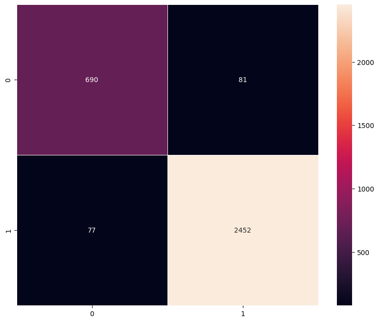

```python
plot_confusion_matrix(model_4,X_train_normalized,y_train)
```

```python
model_4_valid_perf = model_performance_classification(model_4, X_val_normalized,y_val)

print("Validation performance metrics")
print(model_4_valid_perf)
```

```
13/13 ━━━━━━━━━━━━━━━━━━━━ 2s 146ms/step
Validation performance metrics
   Accuracy    Recall  Precision  F1 Score
0  0.924757  0.889306   0.898085   0.89358
```

```
13/13 ━━━━━━━━━━━━━━━━━━━━ 2s 146ms/step
```

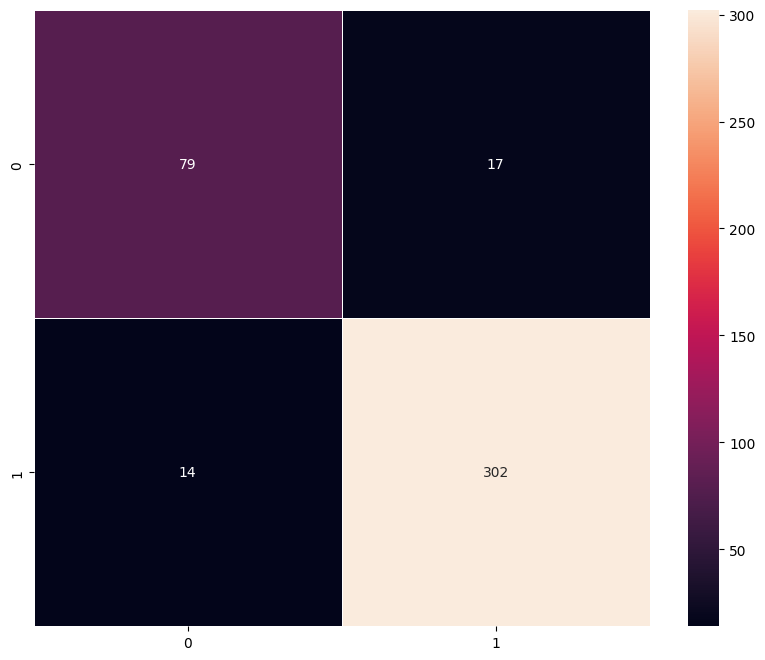

```python
plot_confusion_matrix(model_4,X_val_normalized,y_val)
```

#### Visualizing the predictions

```python
# plt.figure(figsize=(2,2))
# plt.imshow(X_val[_____]) #Complete the code to define the index
# plt.show()
# prediction = model_4.predict(X_val_normalized[_____].reshape(1,200,200,3)) #Complete the code to define the index
# predicted_label = prediction[0][0]>0.5  # Extract the predicted class label
# print('Predicted Label:', 1 if predicted_label else 0)
# # Fix indexing issue in y_val
# true_label = y_val.iloc[_____] #Complete the code to define the index
# print('True Label:', true_label)

# plt.figure(figsize=(2,2))
# plt.imshow(X_val[_____]) #Complete the code to define the index
# plt.show()
# prediction = model_4.predict(X_val_normalized[_____].reshape(1,200,200,3)) #Complete the code to define the index
# predicted_label = prediction[0][0]>0.5  # Extract the predicted class label
# print('Predicted Label:', 1 if predicted_label else 0)
# # Fix indexing issue in y_val
# true_label = y_val.iloc[_____] #Complete the code to define the index
# print('True Label:', true_label)
```

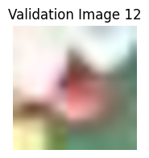

```
Helmet probability: 0.9357
Predicted Label: 1
True Label: 1
Prediction Correct: True
```

```python
# Prediction for validation image 12
plt.figure(figsize=(2, 2))
plt.imshow(X_val[12])
plt.axis("off")
plt.title("Validation Image 12")
plt.show()

prediction = model_4.predict(
    X_val_normalized[12].reshape(
        1, 200, 200, 3
    ),
    verbose=0
)

helmet_probability = float(prediction[0][0])
predicted_label = int(helmet_probability > 0.5)
true_label = int(y_val.iloc[12, 0])

print(
    "Helmet probability:",
    round(helmet_probability, 4)
)
print("Predicted Label:", predicted_label)
print("True Label:", true_label)
print(
    "Prediction Correct:",
    predicted_label == true_label
)
```

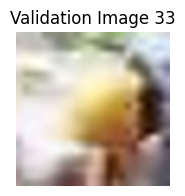

```
Helmet probability: 0.9393
Predicted Label: 1
True Label: 1
Prediction Correct: True
```

```python
# Prediction for validation image 33
plt.figure(figsize=(2, 2))
plt.imshow(X_val[33])
plt.axis("off")
plt.title("Validation Image 33")
plt.show()

prediction = model_4.predict(
    X_val_normalized[33].reshape(
        1, 200, 200, 3
    ),
    verbose=0
)

helmet_probability = float(prediction[0][0])
predicted_label = int(helmet_probability > 0.5)
true_label = int(y_val.iloc[33, 0])

print(
    "Helmet probability:",
    round(helmet_probability, 4)
)
print("Predicted Label:", predicted_label)
print("True Label:", true_label)
print(
    "Prediction Correct:",
    predicted_label == true_label
)
```

# **Model Performance Comparison and Final Model Selection**

```python
# training performance comparison

models_train_comp_df = pd.concat(
    [
        model_1_train_perf.T,
        model_2_train_perf.T,
        model_3_train_perf.T,
        model_4_train_perf.T,
    ],
    axis=1,
)
models_train_comp_df.columns = [
    "Simple Convolutional Neural Network (CNN)","VGG-16 (Base)","VGG-16 (Base+FFNN)","VGG-16 (Base+FFNN+Data Aug)"
]
```

```python
models_valid_comp_df = pd.concat(
    [
        model_1_valid_perf.T,
        model_2_valid_perf.T,
        model_3_valid_perf.T,
        model_4_valid_perf.T

    ],
    axis=1,
)
models_valid_comp_df.columns = [
 "Simple Convolutional Neural Network (CNN)","VGG-16 (Base)","VGG-16 (Base+FFNN)","VGG-16 (Base+FFNN+Data Aug)"
]
```

```python
models_train_comp_df
```

|  | Simple Convolutional Neural Network (CNN) | VGG-16 (Base) | VGG-16 (Base+FFNN) | VGG-16 (Base+FFNN+Data Aug) |
| --- | --- | --- | --- | --- |
| Accuracy | 0.930909 | 0.974545 | 0.946970 | 0.952121 |
| Recall | 0.880991 | 0.958599 | 0.905445 | 0.932247 |
| Precision | 0.921119 | 0.969774 | 0.943736 | 0.933815 |
| F1 Score | 0.898842 | 0.964034 | 0.922703 | 0.933028 |

```python
models_valid_comp_df
```

|  | Simple Convolutional Neural Network (CNN) | VGG-16 (Base) | VGG-16 (Base+FFNN) | VGG-16 (Base+FFNN+Data Aug) |
| --- | --- | --- | --- | --- |
| Accuracy | 0.919903 | 0.919903 | 0.919903 | 0.924757 |
| Recall | 0.875264 | 0.871638 | 0.849881 | 0.889306 |
| Precision | 0.896007 | 0.898727 | 0.919941 | 0.898085 |
| F1 Score | 0.884989 | 0.884095 | 0.878241 | 0.893580 |

```python
models_train_comp_df - models_valid_comp_df
```

|  | Simple Convolutional Neural Network (CNN) | VGG-16 (Base) | VGG-16 (Base+FFNN) | VGG-16 (Base+FFNN+Data Aug) |
| --- | --- | --- | --- | --- |
| Accuracy | 0.011006 | 0.054643 | 0.027067 | 0.027364 |
| Recall | 0.005728 | 0.086961 | 0.055563 | 0.042941 |
| Precision | 0.025113 | 0.071047 | 0.023795 | 0.035730 |
| F1 Score | 0.013852 | 0.079939 | 0.044462 | 0.039448 |

## Test Performance

```python
models_valid_comp_df
```

|  | Simple Convolutional Neural Network (CNN) | VGG-16 (Base) | VGG-16 (Base+FFNN) | VGG-16 (Base+FFNN+Data Aug) |
| --- | --- | --- | --- | --- |
| Accuracy | 0.919903 | 0.919903 | 0.919903 | 0.924757 |
| Recall | 0.875264 | 0.871638 | 0.849881 | 0.889306 |
| Precision | 0.896007 | 0.898727 | 0.919941 | 0.898085 |
| F1 Score | 0.884989 | 0.884095 | 0.878241 | 0.893580 |

```python
# Assign the selected validation model
best_model = model_4
best_model_name = "VGG-16 (Base+FFNN+Data Aug)"

# Evaluate it on the test dataset
model_test_perf = model_performance_classification(
    best_model,
    X_test_normalized,
    y_test
)

print("Selected model:", best_model_name)
print("Test performance metrics:")
print(model_test_perf)
```

```
13/13 ━━━━━━━━━━━━━━━━━━━━ 3s 162ms/step
Selected model: VGG-16 (Base+FFNN+Data Aug)
Test performance metrics:
   Accuracy    Recall  Precision  F1 Score
0  0.891041  0.853778   0.846454  0.850016
```

```python
plot_confusion_matrix(
    best_model,
    X_test_normalized,
    y_test
)
```

[output not shown]

```
13/13 ━━━━━━━━━━━━━━━━━━━━ 2s 159ms/step
```

```python
model_test_perf = model_performance_classification(
    model_4,
    X_test_normalized,
    y_test
)
```

```
13/13 ━━━━━━━━━━━━━━━━━━━━ 2s 145ms/step
```

```python
plot_confusion_matrix(
    model_4,
    X_test_normalized,
    y_test
)
```

[output not shown]

```
13/13 ━━━━━━━━━━━━━━━━━━━━ 2s 155ms/step
```

```python
model_test_perf = model_performance_classification(best_model, X_test_normalized,y_test) #Complete the code to pass the best model (Pass the variable corresponding to it. For example, model_1)
```

```
13/13 ━━━━━━━━━━━━━━━━━━━━ 2s 156ms/step
```

```python
model_test_perf
```

|  | Accuracy | Recall | Precision | F1 Score |
| --- | --- | --- | --- | --- |
| 0 | 0.891041 | 0.853778 | 0.846454 | 0.850016 |

```python
plot_confusion_matrix( best_model, X_test_normalized,y_test) #Complete the code to pass the best model (Pass the variable corresponding to it. For example, model_1)
```

[output not shown]

```
13/13 ━━━━━━━━━━━━━━━━━━━━ 2s 157ms/step
```

## Model 4: VGG16 with FFNN and Data Augmentation

### Model Configuration

Model 4 combines:

- A pretrained VGG16 convolutional base
- A feed-forward neural network classification head
- Data augmentation applied only to the training images

The VGG16 layers were frozen, so their pretrained ImageNet weights were not changed during training.

The classification head contained:

- A `Flatten` layer
- A dense layer with 64 neurons and ReLU activation
- A dropout layer with a rate of `0.30`
- A dense layer with 32 neurons and ReLU activation
- One sigmoid output neuron for binary classification

The model used:

- **Optimizer:** Adam
- **Learning rate:** `0.0001`
- **Loss:** Binary cross-entropy
- **Batch size:** `16`
- **Tracked Keras metric:** Recall

### Data Augmentation

The training images were augmented using:

- Rotation of up to 15 degrees
- Horizontal shifting of up to 10%
- Vertical shifting of up to 10%
- Shearing of up to 10%
- Zooming of up to 10%
- Horizontal flipping
- No vertical flipping

These transformations exposed the model to additional variation in worker position, image framing, camera angle, and orientation.

Only the training images were augmented. The validation and test images remained unchanged so that they could provide realistic evaluations of model performance.

> **Important training note:** Model 4 was trained in two consecutive calls to `model.fit()`, with 10 epochs in each call. Because the model was not rebuilt between the calls, the current results represent **20 total training epochs**. The results should therefore be considered provisional when comparing Model 4 with models trained for only 10 epochs.

## Training Performance

The final training metrics were:

| Metric | Training Result |
| --- | --- |
| Accuracy | 0.9521 |
| Macro recall | 0.9322 |
| Macro precision | 0.9338 |
| Macro F1-score | 0.9330 |

The model correctly classified approximately **95.2%** of the 3,300 training images.

### Training Confusion Matrix

| Actual class | Predicted Without Helmet | Predicted With Helmet |
| --- | --- | --- |
| Without Helmet | 690 | 81 |
| With Helmet | 77 | 2,452 |

This means:

- **690** no-helmet images were classified correctly.
- **81** no-helmet images were incorrectly classified as helmeted.
- **77** helmet images were incorrectly classified as no-helmet.
- **2,452** helmet images were classified correctly.
- The model made **158 training errors**.
- The model made **3,142 correct training predictions**.

Class-specific training recall was:

- **Without Helmet:** `690 ÷ 771 = 89.5%`
- **With Helmet:** `2,452 ÷ 2,529 = 97.0%`

The model performed better on helmet images than no-helmet images, even on the training dataset.

## Validation Performance

The validation metrics were:

| Metric | Validation Result |
| --- | --- |
| Accuracy | 0.9248 |
| Macro recall | 0.8893 |
| Macro precision | 0.8981 |
| Macro F1-score | 0.8936 |

The model correctly classified approximately **92.5%** of the 412 validation images.

### Validation Confusion Matrix

| Actual class | Predicted Without Helmet | Predicted With Helmet |
| --- | --- | --- |
| Without Helmet | 79 | 17 |
| With Helmet | 14 | 302 |

This means:

- **79** no-helmet images were classified correctly.
- **17** no-helmet images were incorrectly classified as helmeted.
- **14** helmet images were incorrectly classified as no-helmet.
- **302** helmet images were classified correctly.
- The model made **31 validation errors**.
- The model made **381 correct validation predictions**.

Class-specific validation recall was:

- **Without Helmet:** `79 ÷ 96 = 82.3%`
- **With Helmet:** `302 ÷ 316 = 95.6%`

The model was substantially better at recognizing helmet images than no-helmet images.

### Safety Interpretation

The most consequential validation errors were the **17 no-helmet images incorrectly classified as helmeted**.

These errors represented:

$$ \frac{17}{96}\times100 \approx 17.7\% $$

of the actual no-helmet validation images.

In an operational safety-monitoring system, these cases could represent workers who are not wearing helmets but are incorrectly identified as compliant.

## Training-to-Validation Generalization

| Metric | Training | Validation | Difference |
| --- | --- | --- | --- |
| Accuracy | 0.9521 | 0.9248 | 0.0274 |
| Macro recall | 0.9322 | 0.8893 | 0.0429 |
| Macro precision | 0.9338 | 0.8981 | 0.0357 |
| Macro F1-score | 0.9330 | 0.8936 | 0.0394 |

Validation performance was approximately three to four percentage points lower than training performance. This indicates some overfitting, although Model 4 generalized better than the VGG16 base model without augmentation.

The comparison must be interpreted cautiously because Model 4 was accidentally trained for 20 total epochs.

## Model Comparison

The validation results for all four models were:

| Model | Accuracy | Macro Recall | Macro Precision | Macro F1 |
| --- | --- | --- | --- | --- |
| CNN from Scratch | 0.9199 | 0.8753 | 0.8960 | 0.8850 |
| VGG16 Base | 0.9199 | 0.8716 | 0.8987 | 0.8841 |
| VGG16 Base + FFNN | 0.9199 | 0.8499 | **0.9199** | 0.8782 |
| VGG16 Base + FFNN + Augmentation | **0.9248** | **0.8893** | 0.8981 | **0.8936** |

Model 4 achieved the highest:

- Validation accuracy
- Validation macro recall
- Validation macro F1-score

Model 3 achieved the highest macro precision, but its lower recall and F1-score indicated less balanced performance.

Based on the available validation evidence, Model 4 was selected for final test evaluation.

## Test Performance

The provisional Model 4 test metrics were:

| Metric | Test Result |
| --- | --- |
| Accuracy | 0.8910 |
| Macro recall | 0.8538 |
| Macro precision | 0.8465 |
| Macro F1-score | 0.8500 |

The model correctly classified approximately **89.1%** of the 413 test images.

### Test Confusion Matrix

| Actual class | Predicted Without Helmet | Predicted With Helmet |
| --- | --- | --- |
| Without Helmet | 76 | 21 |
| With Helmet | 24 | 292 |

This means:

- **76** no-helmet images were classified correctly.
- **21** no-helmet images were incorrectly classified as helmeted.
- **24** helmet images were incorrectly classified as no-helmet.
- **292** helmet images were classified correctly.
- The model made **45 test errors**.
- The model made **368 correct test predictions**.

Class-specific test recall was:

- **Without Helmet:** `76 ÷ 97 = 78.4%`
- **With Helmet:** `292 ÷ 316 = 92.4%`

The model remained more effective at detecting helmet images than no-helmet images.

### Test Safety Interpretation

The model incorrectly classified 21 of the 97 no-helmet test images as helmeted.

This represents:

$$ \frac{21}{97}\times100 \approx 21.6\% $$

of the unsafe no-helmet test cases.

At the default probability threshold of `0.5`, the model failed to flag approximately one out of every five no-helmet images in this test sample.

The 24 helmet images classified as no-helmet would create false alarms. These errors could increase the need for human review, but they are generally less safety-critical than failing to identify an unprotected worker.

## Validation-to-Test Generalization

| Metric | Validation | Test | Decline |
| --- | --- | --- | --- |
| Accuracy | 0.9248 | 0.8910 | 0.0337 |
| Macro recall | 0.8893 | 0.8538 | 0.0355 |
| Macro precision | 0.8981 | 0.8465 | 0.0516 |
| Macro F1-score | 0.8936 | 0.8500 | 0.0436 |

Test performance was approximately three to five percentage points lower than validation performance.

This indicates that the validation results somewhat overestimated performance on the independent test set. Nevertheless, the test accuracy remained above the **76.6% majority-class baseline**.

## Keras Recall Compared with Macro Recall

Keras recall treats label `1`, **With Helmet**, as the positive class. It primarily measures how effectively the model recognizes helmet images.

Macro recall calculates recall separately for both classes and gives them equal weight.

For the test dataset:

- No-helmet recall: **78.4%**
- Helmet recall: **92.4%**

Therefore:

$$ \text{Macro Recall} = \frac{78.4\%+92.4\%}{2} \approx85.4\% $$

This explains why macro recall is lower than the Keras recall reported for the helmet class.

Macro recall provides a more balanced assessment because it gives equal importance to the helmet and no-helmet classes.

## Overall Model 4 Conclusion

Model 4 produced the strongest provisional validation results among the four models:

- **Validation accuracy:** 92.5%
- **Validation macro recall:** 88.9%
- **Validation macro F1-score:** 89.4%

Its provisional test results were:

- **Test accuracy:** 89.1%
- **Test macro recall:** 85.4%
- **Test macro precision:** 84.6%
- **Test macro F1-score:** 85.0%

Data augmentation appears to have improved validation performance relative to the non-augmented VGG16 models. However, Model 4 remained significantly better at identifying helmet images than unsafe no-helmet images.

The principal operational limitation is that the model incorrectly classified approximately **21.6% of no-helmet test images as helmet-compliant**. The model should therefore not be used as the sole safety-enforcement mechanism without additional evaluation and human oversight.

### Recommended Next Steps

1. Rebuild Model 4 and train it once for 10 epochs to ensure a controlled comparison.
2. Do not change the model configuration based on the previously viewed test results.
3. Evaluate alternative probability thresholds using validation data.
4. Collect additional no-helmet images to reduce class imbalance.
5. Add more blurred, obstructed, distant, and low-light training examples.
6. Route low-confidence predictions to a human reviewer.
7. Test performance across different sites, cameras, lighting conditions, worker populations, and helmet styles.
8. Monitor no-helmet recall and false-compliance errors after deployment.
9. Use the model as a decision-support tool rather than an autonomous enforcement system.

### Concise Observation for the Presentation

Model 4 achieved the strongest provisional validation performance, with 92.5% accuracy and an 89.4% macro F1-score. Test performance declined to 89.1% accuracy and an 85.0% macro F1-score. The model correctly identified 92.4% of helmet images but only 78.4% of no-helmet images, incorrectly classifying 21 of 97 unsafe test cases as helmet-compliant. Additional minority-class data, threshold optimization, and human review are recommended before operational use.

# **Actionable Insights & Recommendations**

# Actionable Insights and Recommendations

## Provisional Final Model Selection

Model 4, **VGG16 Base with FFNN and Data Augmentation**, produced the strongest available validation results.

Its validation performance was:

| Metric | Validation Result |
| --- | --- |
| Accuracy | 0.9248 |
| Macro recall | 0.8893 |
| Macro precision | 0.8981 |
| Macro F1-score | 0.8936 |

Model 4 achieved the highest validation accuracy, macro recall, and macro F1-score among the four evaluated models. It therefore provided the strongest balance between overall classification performance and class-specific recall.

However, this selection must be considered **provisional** for two reasons:

1. Model 1 was originally trained with a ReLU output instead of the sigmoid activation required for binary classification.
2. Model 4 was trained in two consecutive 10-epoch calls, resulting in 20 total epochs, while the other models were trained for 10 epochs.

A controlled comparison requires Model 1 to be rebuilt with a sigmoid output and Model 4 to be rebuilt and trained once for 10 epochs.

The model architecture and hyperparameters should not be adjusted based on the test results that have already been observed.

## Provisional Test Performance

The provisional Model 4 test results were:

| Metric | Test Result |
| --- | --- |
| Accuracy | 0.8910 |
| Macro recall | 0.8538 |
| Macro precision | 0.8465 |
| Macro F1-score | 0.8500 |

The model correctly classified:

```
368 of 413 test images
```

and made:

```
45 test errors
```

Although the test accuracy exceeded the 76.6% majority-class baseline, performance declined relative to validation results.

| Metric | Validation | Test | Decline |
| --- | --- | --- | --- |
| Accuracy | 0.9248 | 0.8910 | 0.0337 |
| Macro recall | 0.8893 | 0.8538 | 0.0355 |
| Macro precision | 0.8981 | 0.8465 | 0.0516 |
| Macro F1-score | 0.8936 | 0.8500 | 0.0436 |

This decline indicates that validation performance somewhat overestimated performance on the independent test dataset.

## Safety Implications

Overall accuracy should not be considered alone because the dataset contains substantially more helmet images than no-helmet images.

The final test confusion matrix showed:

| Actual class | Predicted Without Helmet | Predicted With Helmet |
| --- | --- | --- |
| Without Helmet | 76 | 21 |
| With Helmet | 24 | 292 |

Therefore:

- **76** no-helmet images were classified correctly.
- **21** no-helmet images were incorrectly classified as helmeted.
- **24** helmet images were incorrectly classified as no-helmet.
- **292** helmet images were classified correctly.

### No-Helmet Detection

No-helmet recall was:

```
76 ÷ 97 = 78.4%
```

The model incorrectly classified:

```
21 ÷ 97 = 21.6%
```

of the actual no-helmet test images as helmet-compliant.

This is the most consequential error because it may allow an unsafe condition to go undetected.

### Helmet Detection

Helmet recall was:

```
292 ÷ 316 = 92.4%
```

The model was therefore substantially more effective at recognizing helmet images than no-helmet images.

The 24 helmet images classified as no-helmet would generate false alarms and unnecessary reviews. However, these errors are generally less safety-critical than incorrectly declaring an unprotected worker compliant.

### Primary Operational Finding

At the default probability threshold of `0.5`, the model failed to flag approximately one out of every five no-helmet test images.

This error rate is too high for the model to serve as the sole safety-enforcement mechanism.

## Key Actionable Insights

### 1. Overall accuracy overstates operational effectiveness

The model achieved 89.1% test accuracy, but no-helmet recall was only 78.4%. The class imbalance allows strong overall accuracy even when the model misses a meaningful percentage of unsafe cases.

Model evaluation should prioritize:

- No-helmet recall
- Macro recall
- Macro F1-score
- Number of unsafe false-compliance errors
- Training-validation-test consistency

### 2. Standard Keras recall measures the less critical class

Because label `1` represents With Helmet, the standard Keras recall metric measures helmet recall.

It does not directly measure the model's ability to detect workers without helmets.

The project should continue reporting:

- Helmet recall
- No-helmet recall
- Macro recall
- Confusion matrices

### 3. Data augmentation improved validation performance but did not eliminate the safety gap

Model 4 achieved the strongest validation macro F1-score, suggesting that augmentation helped the model generalize across variations in image position, framing, and orientation.

However, data augmentation did not eliminate the model's weaker performance on no-helmet images.

### 4. Image quality is a material source of risk

The dataset includes blurred, obstructed, distant, poorly framed, and low-resolution images. These conditions can make helmet status difficult to determine even for a human reviewer.

Image-quality checks should be incorporated into any future system so that unreadable images are not treated as confident compliance decisions.

### 5. Whole-image classification may not be sufficient for real deployment

The current models classify an entire image as With Helmet or Without Helmet. They do not locate individual workers or determine helmet status separately for each person.

This creates a limitation when:

- An image contains multiple workers.
- Some workers are wearing helmets and others are not.
- A helmet appears in the background.
- The relevant worker occupies only a small part of the image.

A production system may require person detection followed by person-level helmet classification or an object-detection model that localizes both workers and helmets.

## Recommendations

### 1. Correct and rerun the model comparison

Before finalizing the academic comparison:

- Rebuild Model 1 with `Dense(1, activation="sigmoid")`.
- Rebuild Model 4 from its initial weights.
- Train Model 4 once for 10 epochs.
- Regenerate all training and validation metrics.
- Recreate the model-comparison tables.
- Confirm the final model using validation results only.

### 2. Prioritize no-helmet recall in model selection

The final selection criterion should explicitly consider unsafe false-compliance errors.

If two models have similar macro F1-scores, preference should be given to the model that:

- Correctly identifies more no-helmet images.
- Misclassifies fewer unprotected workers as compliant.
- Maintains an acceptable false-alarm rate.
- Demonstrates a smaller generalization gap.

### 3. Evaluate a more conservative probability threshold

The current decision threshold is:

```
0.5
```

Because label `1` means With Helmet, the model declares compliance whenever the helmet probability exceeds `0.5`.

A higher helmet threshold would require stronger evidence before declaring a worker compliant. This could improve no-helmet recall and reduce unsafe false-compliance errors, although it would also generate more false alarms.

Alternative thresholds must be selected using validation data—not test data.

### 4. Address the class imbalance

The training dataset contains substantially fewer no-helmet images than helmet images.

Future training should consider:

- Collecting additional no-helmet images
- Class-weighted binary cross-entropy
- Balanced batch sampling
- Carefully controlled minority-class augmentation
- Reporting class-specific performance after each experiment

### 5. Improve data quality and label quality

Future data collection should include more representative examples involving:

- Low-light environments
- Blurred images
- Partial occlusion
- Distant workers
- Side and rear views
- Different helmet colors and styles
- Different work sites and camera systems
- Multiple workers in one image

Ambiguous or severely blurred images should be reviewed for labeling accuracy.

### 6. Use human review for uncertain cases

The model should operate as a decision-support system rather than an autonomous enforcement mechanism.

Images should be routed to a human reviewer when:

- Helmet probability is close to the decision threshold.
- Image quality is poor.
- Multiple workers are present.
- The worker's head is obstructed.
- The model and an image-quality check disagree.

### 7. Validate across operational environments

Before deployment, the model should be evaluated across:

- Different construction and industrial sites
- Different camera positions and resolutions
- Indoor and outdoor lighting conditions
- Different weather conditions
- Different worker populations
- Different helmet colors and designs

Performance on one dataset does not establish reliability across all workplaces.

### 8. Monitor performance after deployment

Ongoing monitoring should include:

- No-helmet recall
- Unsafe false-compliance rate
- False-alarm rate
- Confidence-score distribution
- Image-quality failures
- Performance drift over time
- Performance differences across sites and operating conditions

Periodic human audits should identify emerging failure patterns and determine when retraining is required.

### 9. Maintain privacy and governance controls

Workplace image monitoring should include:

- Appropriate access controls
- Defined image-retention periods
- Secure data storage
- Documented authorized uses
- Worker notification where required
- Periodic privacy and governance reviews

## Final Conclusion

The project demonstrates that CNNs and transfer learning can classify helmet use from workplace images. Model 4 produced the strongest provisional validation performance and achieved 89.1% test accuracy with an 85.0% macro F1-score.

However, the model correctly identified only 78.4% of no-helmet test images and incorrectly classified 21 of 97 unsafe cases as helmet-compliant.

These results demonstrate that strong overall accuracy does not guarantee reliable safety performance. The current model shows potential as a screening and decision-support tool, but it is not ready to serve as an autonomous safety-enforcement system.

The final deployment decision should prioritize:

- No-helmet recall
- Unsafe false-compliance errors
- Balanced class performance
- External validation
- Human review
- Continuous monitoring
- Privacy and governance controls

### Concise Recommendation for the Presentation

Model 4 produced the strongest provisional validation performance, but it missed 21.6% of no-helmet test cases. SafeGuard Corp should use the model only as a human-supervised screening tool while improving minority-class representation, evaluating a more conservative compliance threshold, expanding person-level detection capabilities, and validating performance across operational environments.

Power Ahead!